# Replication code: Reputation management during a public health crisis: Overcompensating when all else fails. PAR, 2023.

Varela Castro, Bustos & Saldivia Gonzatti

25 4 2023

# Press conferences by the Mexican Health Secretariat, analysis

```r
load("data/datos_valición.medios_gatell.share.RData")
```

## Objects from the file

```r
rm(gatell_sh.random) # This is used in the validation file
rm(strsplit2) # This was used in the conference data generation script
```

## Get automatically translated Spanish sentiment dictionary

Download from Harvard dataverse with . Source: Proksch, S.-O., Lowe, W., Wäckerle, J. and Soroka, S. (2019), Multilingual Sentiment Analysis: A New Approach to Measuring Conflict in Legislative Speeches. Legislative Studies Quarterly, 44: 97-131. https://doi.org/10.1111/lsq.12218.

```r
list <- ls()
load("../D_Data/auto_dictionaries_lsd.RData")
rm(list=setdiff(ls(), c("extendeddict_es", list)))
```

## Visualizing number of actors

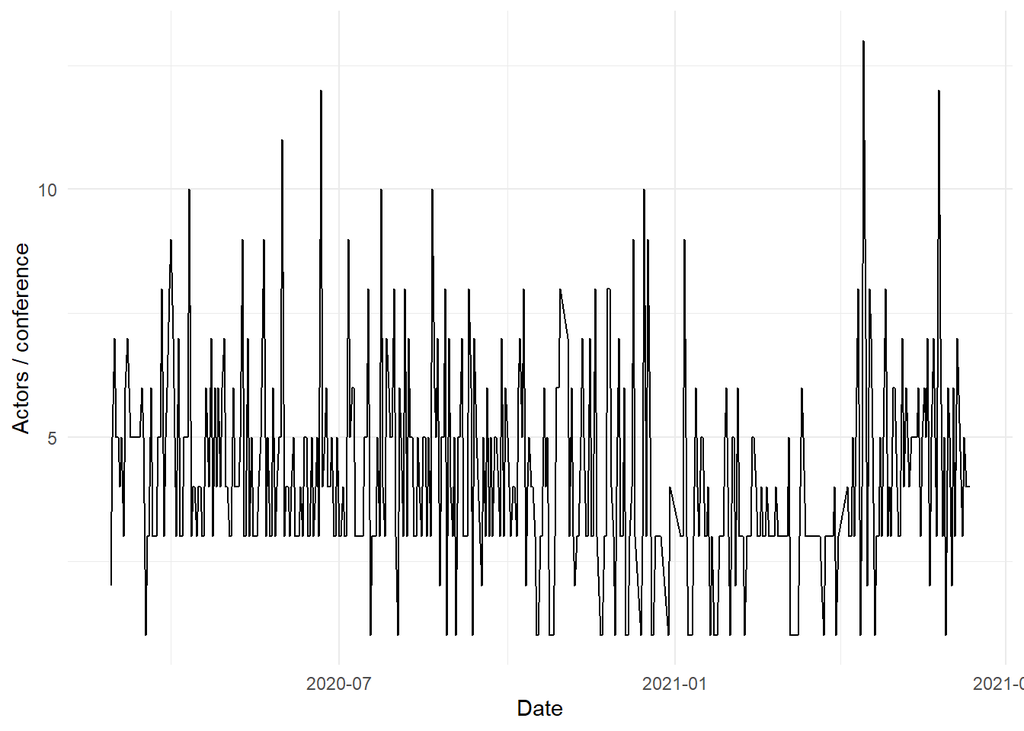

```r
actor_number <- data_interventions %>% filter(!grepl("^PREGUNTA$|^INTERLOCUTOR(|A)", actor_name)) %>%
  dplyr::select(actor, date) %>%
  filter(!duplicated(.)) %>%
  group_by(date) %>% summarise(actors_number = n())


ggplot(actor_number, aes(x = date, y = actors_number)) + geom_line() + theme_minimal() + ylab("Actors / conference") +
  xlab("Date")
```

```r
summary(actor_number$actors_number)
```

```
##    Min. 1st Qu.  Median    Mean 3rd Qu.    Max.
##    1.00    3.00    4.00    4.22    5.00   13.00
```

## Aggregated Twitter sentiment data (legitimacy)

Load and visualize data

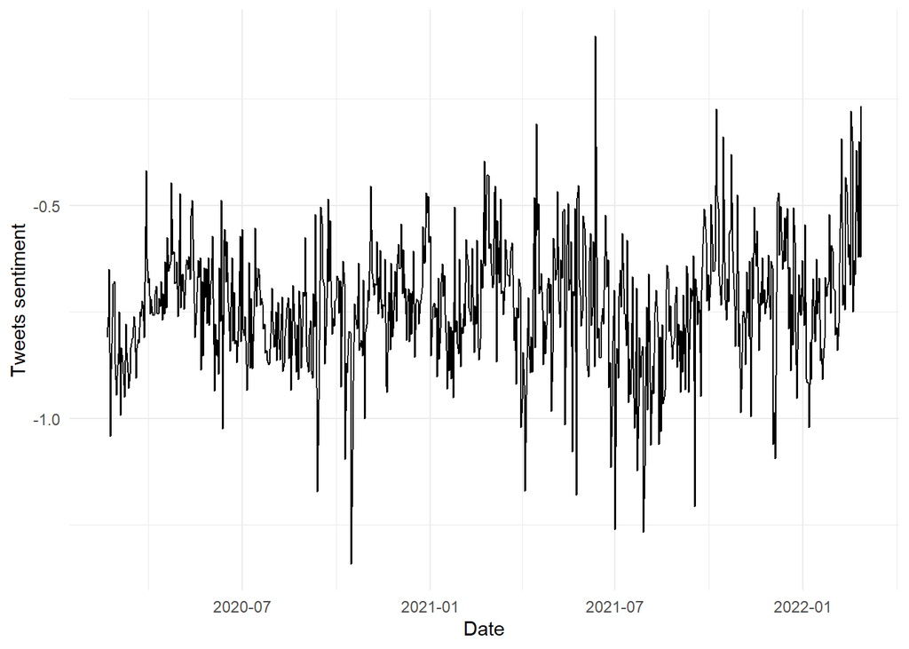

```r
load("data/twitter_aggregated.RData")

ggplot(tw.daily_sentiment.legit, aes(x = date, y = sentiment)) + geom_line() + theme_minimal() + ylab("Tweets sentiment") +
  xlab("Date")
```

## Prep press conference intervention data

```r
data_interventions <- data_interventions %>%
  mutate(across(c(funcional:tecnico), ~ ./words*100, .names = "{.col}_share"))

data_interventions.aggr <- data_interventions %>% group_by(date) %>%
  summarise(intervention_text.day = paste0(intervention_text, collapse = " "),
            words_total = sum(words, na.rm = TRUE),
            funcional = sum(funcional, na.rm = TRUE),
            legal = sum(legal, na.rm = TRUE),
            moral = sum(moral, na.rm =  TRUE),
            tecnico = sum(tecnico, na.rm = TRUE)) %>% ungroup()

data_interventions.aggr <- data_interventions.aggr %>% left_join(actor_number)
```

## Prepare and merge Twitter data

```r
tw.daily_sentiment.legit <- tw.daily_sentiment.legit %>% arrange(date) %>%
  mutate(sentiment_week.ma = zoo::rollapply(sentiment, 7, mean, align='right', fill=NA))
data_interventions.aggr <- data_interventions.aggr %>% left_join(tw.daily_sentiment.legit)
```

Previous transformations conducted here were droppe from the analysis.

## Covid-19 official death toll

Load, adapt and merge data

```r
covid.deaths <- read.csv(file = "data/Casos_Diarios_Estado_Nacional_Defunciones_20220121.csv") %>%
  filter(nombre=="Nacional") %>% t() %>% as.data.frame() %>%
  tibble::rownames_to_column("date") %>%
  mutate(population = 127792286) %>%
  filter(grepl("X",date)) %>% mutate(date = lubridate::dmy(gsub("X","",date))) %>%
  dplyr::rename(deaths = `V1`) %>%
  mutate(deaths = as.numeric(deaths),
         incidende = deaths/population*100000)

covid.deaths <- covid.deaths %>% arrange(date) %>%
  mutate(deaths_week.ma = zoo::rollapply(deaths,7, mean, align='right', fill=NA))


data_interventions.aggr <- data_interventions.aggr %>% left_join(covid.deaths)

data_interventions.aggr <- data_interventions.aggr %>%
  mutate(across(c(funcional:tecnico), ~ ./words_total*100, .names = "{.col}_share")) %>%
  mutate(across(c(funcional_share:tecnico_share), ~ .-mean(.), .names = "{.col}.cent"))
```

Previous analyses conducted here have been dropped.

## Create and visualize final indicators

This code generates Figure 2 of the paper: “Reputational Dimensions in Press Conferences by the Health Secretariat and COVID-19 Deaths in Mexico, 2020-2021”.

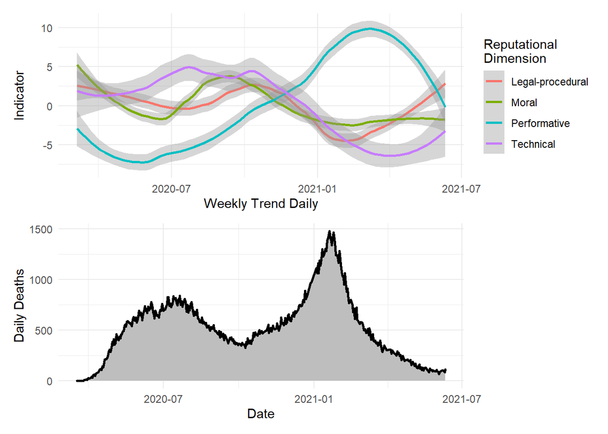

```r
data_indicadores <- data_interventions.aggr %>%
  dplyr::select(date, actors_number, deaths, deaths_week.ma, sentiment,
                sentiment_week.ma,funcional_share.cent:tecnico_share.cent) %>%
  pivot_longer(!date, names_to = "dimension", values_to = "value")

data_indicadores <- data_indicadores %>% group_by(dimension) %>%
  mutate(mean_dimension = mean(value, na.rm = TRUE)) %>%
  ungroup() %>%
  mutate(indicador = value-mean_dimension+0)

data_indicadores <- data_indicadores %>% ungroup() %>% arrange(dimension,date) %>%
  group_by(dimension) %>%
  mutate(indicador_week.ma = zoo::rollapply(indicador,7, mean, align='right', fill=NA)) %>% ungroup() %>%
  mutate(`Reputational dimension` = case_when(dimension == "funcional_share.cent" ~ "Performative",
                                              dimension == "legal_share.cent" ~ "Legal-procedural",
                                              dimension == "tecnico_share.cent" ~ "Technical",
                                              dimension == "moral_share.cent" ~ "Moral"))

# For illustration purposes, we multiply the indicators/indices by 100.
# Since the indicator is interesting only in relative change, this adaption only simplifies readability.

reputation_gr <- ggplot(data_indicadores %>% dplyr::rename(`Reputational\nDimension` = `Reputational dimension`) %>%
                          filter(!grepl("Flesch|senti[.]ton|senti|actor", `Reputational\nDimension`)) %>%
                          filter(!is.na(`Reputational\nDimension`)),
       aes(x = date, y = indicador_week.ma*100,  colour = `Reputational\nDimension`)) +
  geom_smooth(span = 0.5) + theme_minimal() + xlab("Weekly Trend Daily") + ylab("Indicator") #+

deaths_gr <- ggplot(data_indicadores %>% filter(dimension=="deaths"))+ ylab("Daily Deaths") + xlab("Date") +
  geom_area(aes(x = date, y = value), fill="grey", colour="black", size = 1) + theme_minimal()

reputation_gr/deaths_gr # Use "patchwork" package.
```

## Transform, complete and generate lead values in the data (including change scores)

```r
data_meta <- data_interventions.aggr %>% dplyr::select(date, deaths, deaths_week.ma, sentiment, sentiment_week.ma,
                                                       actors_number) %>%
  filter(!duplicated(.))

data_indicadores <- data_indicadores %>% left_join(data_meta)
gatell_dates     <- gatell %>% dplyr::select(date) %>% mutate(gatell = 1) %>% filter(!duplicated(.))
data_indicadores <- data_indicadores %>% left_join(gatell_dates)
data_indicadores <- data_indicadores %>% mutate(gatell = ifelse(is.na(gatell),0,gatell))

# data_indicadores %>% filter(dimension=="legal_share.cent") %>% summarise(mean(gatell))

data_indicadores <- data_indicadores %>% arrange(dimension, date) %>%
  group_by(dimension) %>%
  mutate(lead.indicador = dplyr::lead(indicador, n = 1, default = NA),
         lead.deaths = dplyr::lead(deaths, n = 1, default = NA),
         lead.value = dplyr::lead(value, n = 1, default = NA),
         lead.sentiment = dplyr::lead(sentiment , n = 1, default = NA),
         lead.actors_number = dplyr::lead(actors_number , n = 1, default = NA),
         id = row_number()) %>% ungroup() %>%
  mutate(indicador_change = lead.indicador-indicador,
         deaths_change = lead.deaths-deaths)
```

## Main analyses including sub-analyses

```r
options(scipen = 999)

granger_tests <- data.frame()
issue_list <- c("Performative","Legal-procedural","Moral","Technical")

for(p in 1:7){
for(is in 1:4){
  issue_ts <- ts(data_indicadores %>% filter(`Reputational dimension`==issue_list[is]) %>%
                 dplyr::select(indicador),
               start = c(1, 1),
               end = c(444, 1),
               frequency = 1)

  deaths_ts <- ts(data_indicadores %>% filter(`Reputational dimension`==issue_list[is]) %>%
                    dplyr::select(deaths),
                  start = c(1, 1),
                  end = c(444, 1),
                  frequency = 1)

  deaths.week_ma_ts <- ts(data_indicadores %>% filter(`Reputational dimension`==issue_list[is]) %>%
                    dplyr::select(deaths_week.ma),
                  start = c(1, 1),
                  end = c(444, 1),
                  frequency = 1)

  actor.nr_ts <- ts(data_indicadores %>% filter(`Reputational dimension`==issue_list[is]) %>%
                      dplyr::select(actors_number),
                 start = c(1, 1),
                 end = c(444, 1),
                 frequency = 1)
  sentiment_ts <- ts(data_indicadores %>% filter(`Reputational dimension`==issue_list[is]) %>%
                       dplyr::select(sentiment),
                start = c(1, 1),
                end = c(444, 1),
                frequency = 1)

  sentiment.week_ma_ts <- ts(data_indicadores %>% filter(`Reputational dimension`==issue_list[is]) %>%
                       dplyr::select(sentiment_week.ma),
                     start = c(1, 1),
                     end = c(444, 1),
                     frequency = 1)

  gatell_ts <- ts(data_indicadores %>% filter(`Reputational dimension`==issue_list[is]) %>%
                    dplyr::select(gatell),
                     start = c(1, 1),
                     end = c(444, 1),
                     frequency = 1)


  # Models

  VAR_EQ1 <- dynlm(issue_ts ~ L(issue_ts, 1) + L(deaths_ts, 1:p),
                   start = c(1, 25),
                   end = c(444, 1))



  VAR_EQ2 <- dynlm(issue_ts ~ L(issue_ts, 1) +  L(deaths_ts, 1:p) + L(actor.nr_ts, 0) + L(gatell_ts, 0) + L(sentiment.week_ma_ts, 1),
                   start = c(1, 25),
                   end = c(444, 1))

  if(p == 1){
    VAR_EQ1.ma <- dynlm(issue_ts ~ L(issue_ts, 1) + L(deaths.week_ma_ts, 1),
                        start = c(1, 25),
                        end = c(444, 1))
    VAR_EQ2.ma <- dynlm(issue_ts ~ L(issue_ts, 1) +  L(deaths.week_ma_ts, 1) + L(actor.nr_ts, 0) + L(gatell_ts, 0) + L(sentiment.week_ma_ts, 1),
                        start = c(1, 25),
                        end = c(444, 1))

    VAR_EQ3.ma <- dynlm(issue_ts ~ L(issue_ts, 1) + L(sentiment.week_ma_ts, 1),
                        start = c(1, 25),
                        end = c(444, 1))



    granger_tests <- granger_tests %>%
      bind_rows(car::linearHypothesis(VAR_EQ1.ma, hypothesis.matrix = c("L(deaths.week_ma_ts, 1)"), vcov. = sandwich) %>%
                  mutate(type = "SimpleDeath", dimension = issue_list[is]),
                car::linearHypothesis(VAR_EQ2.ma, hypothesis.matrix = c("L(deaths.week_ma_ts, 1)"), vcov. = sandwich) %>%
                  mutate(type = "All", dimension = issue_list[is]),
                car::linearHypothesis(VAR_EQ3.ma, hypothesis.matrix = c("L(sentiment.week_ma_ts, 1)"), vcov. = sandwich) %>%
                  mutate(type = "Sentiment", dimension = issue_list[is]),)

    assign(paste0(issue_list[is],"-","-DimensionByDeathsWEEK-MA"), VAR_EQ1.ma)
    assign(paste0(issue_list[is],"-","-DimensionByAllWEEK-MA"), VAR_EQ2.ma)
    assign(paste0(issue_list[is],"-","-DimensionTwitterWEEK-MA"), VAR_EQ3.ma)

  }

  assign(paste0(issue_list[is],"-","-DimensionByDeaths",p), VAR_EQ1) # Explaining this phenomenon (y)
  assign(paste0(issue_list[is],"-","-DimensionByAll",p), VAR_EQ2) # Explaining this phenomenon (y)

}
}

rm(p, is)
```

## Main results, Table 2

This code generates Table 2 of the paper: “Association Analysis between Health Crisis and Reputational Dimensions, Health Secretariat Mexico - Press Conference”.

```r
stargazer::stargazer(`Performative--DimensionByDeathsWEEK-MA`, `Performative--DimensionByAllWEEK-MA`,
                     `Technical--DimensionByDeathsWEEK-MA`, `Technical--DimensionByAllWEEK-MA`,
                     `Legal-procedural--DimensionByDeathsWEEK-MA`, `Legal-procedural--DimensionByAllWEEK-MA`,
                     `Moral--DimensionByDeathsWEEK-MA`, `Moral--DimensionByAllWEEK-MA`,
                     type = "html", style = "apsr", report = "vc*sp",
                     column.labels = c(rep("Performative",2), rep("Technical",2), rep("Legal",2), rep("Moral",2)),
                     covariate.labels = c("Reputation dimension, t-1", "Covid-19 deaths t-1 - t-7, average",
                                          "# Actors in Conference","Gatell in Conference (0|1)",
                                          "Public Sentiment -> Organization t-1 - t-7, average"))
```

|  | issue_ts |  |  |  |  |  |  |  |
| --- | --- | --- | --- | --- | --- | --- | --- | --- |
|  | Performative | Performative | Technical | Technical | Legal | Legal | Moral | Moral |
|  | (1) | (2) | (3) | (4) | (5) | (6) | (7) | (8) |
| Reputation dimension, t-1 | 0.252*** | 0.174*** | 0.106** | 0.101** | 0.131*** | 0.117** | 0.040 | 0.023 |
|  | (0.047) | (0.047) | (0.049) | (0.049) | (0.049) | (0.048) | (0.049) | (0.047) |
|  | p = 0.00000 | p = 0.0003 | p = 0.030 | p = 0.042 | p = 0.008 | p = 0.015 | p = 0.418 | p = 0.631 |
| Covid-19 deaths t-1 - t-7, average | 0.00004* | 0.00005** | 0.00002 | 0.00000 | -0.00004*** | -0.00005*** | -0.00003* | -0.00002 |
|  | (0.00002) | (0.00002) | (0.00003) | (0.00003) | (0.00002) | (0.00002) | (0.00002) | (0.00002) |
|  | p = 0.053 | p = 0.023 | p = 0.463 | p = 0.914 | p = 0.007 | p = 0.004 | p = 0.078 | p = 0.307 |
| # Actors in Conference |  | 0.010*** |  | -0.011** |  | -0.003 |  | 0.013*** |
|  |  | (0.003) |  | (0.005) |  | (0.003) |  | (0.003) |
|  |  | p = 0.005 |  | p = 0.035 |  | p = 0.295 |  | p = 0.00000 |
| Gatell in Conference (0\|1) |  | -0.123*** |  | 0.040 |  | 0.055*** |  | 0.012 |
|  |  | (0.016) |  | (0.024) |  | (0.012) |  | (0.012) |
|  |  | p = 0.000 |  | p = 0.101 |  | p = 0.00001 |  | p = 0.309 |
| Public Sentiment -> Organization t-1 - t-7, average |  | -0.016 |  | -0.186 |  | -0.078 |  | -0.107 |
|  |  | (0.088) |  | (0.139) |  | (0.067) |  | (0.067) |
|  |  | p = 0.854 |  | p = 0.182 |  | p = 0.243 |  | p = 0.110 |
| Constant | -0.020 | 0.014 | -0.015 | -0.122 | 0.023** | -0.061 | 0.015 | -0.133*** |
|  | (0.013) | (0.064) | (0.020) | (0.101) | (0.010) | (0.048) | (0.010) | (0.048) |
|  | p = 0.128 | p = 0.828 | p = 0.458 | p = 0.230 | p = 0.020 | p = 0.207 | p = 0.139 | p = 0.007 |
| N | 420 | 420 | 420 | 420 | 420 | 420 | 420 | 420 |
| R<sup>2</sup> | 0.077 | 0.197 | 0.013 | 0.030 | 0.040 | 0.094 | 0.010 | 0.095 |
| Adjusted R<sup>2</sup> | 0.073 | 0.187 | 0.008 | 0.018 | 0.035 | 0.083 | 0.005 | 0.084 |
| Residual Std. Error | 0.139 (df = 417) | 0.130 (df = 414) | 0.206 (df = 417) | 0.205 (df = 414) | 0.101 (df = 417) | 0.098 (df = 414) | 0.102 (df = 417) | 0.098 (df = 414) |
| F Statistic | 17.401*** (df = 2; 417) | 20.270*** (df = 5; 414) | 2.720* (df = 2; 417) | 2.545** (df = 5; 414) | 8.701*** (df = 2; 417) | 8.620*** (df = 5; 414) | 2.044 (df = 2; 417) | 8.664*** (df = 5; 414) |
| p < .1; p < .05; p < .01 |  |  |  |  |  |  |  |  |

## Granger causality tests, Table 5 in SM 3

This code generates Table 5 in Supplementary Matrial 3: “Granger causality tests of Table 2 and Table 7”.

```r
granger_tests <- granger_tests %>% filter(!is.na(Df)) %>%
  mutate(Significance = case_when(`Pr(>F)` < 0.10 & `Pr(>F)` >= 0.05 ~ "*",
                                  `Pr(>F)` < 0.05 & `Pr(>F)` >= 0.01 ~ "**",
                                  `Pr(>F)` < 0.01 ~ "***",
                                  TRUE ~ NA_character_))

granger_tests %>% knitr::kable()
```

|  | Res.Df | Df | F | Pr(>F) | type | dimension | Significance |
| --- | --- | --- | --- | --- | --- | --- | --- |
| 2…1 | 417 | 1 | 4.0000918 | 0.0461459 | SimpleDeath | Performative | ** |
| 2…2 | 414 | 1 | 5.9597014 | 0.0150545 | All | Performative | ** |
| 2…3 | 417 | 1 | 0.0650861 | 0.7987564 | Sentiment | Performative | NA |
| 2…4 | 417 | 1 | 8.6774343 | 0.0034023 | SimpleDeath | Legal-procedural | *** |
| 2…5 | 414 | 1 | 10.6903950 | 0.0011669 | All | Legal-procedural | *** |
| 2…6 | 417 | 1 | 0.5660952 | 0.4522393 | Sentiment | Legal-procedural | NA |
| 2…7 | 417 | 1 | 4.1092779 | 0.0432842 | SimpleDeath | Moral | ** |
| 2…8 | 414 | 1 | 1.2961772 | 0.2555711 | All | Moral | NA |
| 2…9 | 417 | 1 | 2.5794302 | 0.1090176 | Sentiment | Moral | NA |
| 2…10 | 417 | 1 | 0.7039410 | 0.4019433 | SimpleDeath | Technical | NA |
| 2…11 | 414 | 1 | 0.0151101 | 0.9022276 | All | Technical | NA |
| 2…12 | 417 | 1 | 2.0087881 | 0.1571369 | Sentiment | Technical | NA |

```r
openxlsx::write.xlsx(granger_tests, file = "results/granger_tests.results.xlsx")
```

## Public Legitimacy Simple Models, Table 6 in SM 4

This code generates Table 6 in the Supplementary Material 4.

```r
stargazer::stargazer(`Performative--DimensionTwitterWEEK-MA`,
                     `Technical--DimensionTwitterWEEK-MA`,
                     `Legal-procedural--DimensionTwitterWEEK-MA`,
                     `Moral--DimensionTwitterWEEK-MA`, type = "html", style = "apsr", report = "vc*sp",
                     column.labels = c(rep("Performative",1), rep("Technical",1), rep("Legal",1), rep("Moral",1)),
                     covariate.labels = c("Reputation dimension, t-1",
                                          "Public Sentiment -> Organization t-1 - t-7, average"))
```

|  | issue_ts |  |  |  |
| --- | --- | --- | --- | --- |
|  | Performative | Technical | Legal | Moral |
|  | (1) | (2) | (3) | (4) |
| Reputation dimension, t-1 | 0.262*** | 0.105** | 0.149*** | 0.042 |
|  | (0.047) | (0.049) | (0.048) | (0.049) |
|  | p = 0.00000 | p = 0.033 | p = 0.003 | p = 0.395 |
| Public Sentiment -> Organization t-1 - t-7, average | -0.025 | -0.192 | -0.052 | -0.107 |
|  | (0.092) | (0.136) | (0.067) | (0.068) |
|  | p = 0.785 | p = 0.160 | p = 0.443 | p = 0.117 |
| Constant | -0.016 | -0.142 | -0.038 | -0.078 |
|  | (0.068) | (0.100) | (0.049) | (0.050) |
|  | p = 0.808 | p = 0.155 | p = 0.443 | p = 0.117 |
| N | 420 | 420 | 420 | 420 |
| R<sup>2</sup> | 0.069 | 0.016 | 0.024 | 0.008 |
| Adjusted R<sup>2</sup> | 0.064 | 0.012 | 0.019 | 0.003 |
| Residual Std. Error (df = 417) | 0.139 | 0.205 | 0.101 | 0.102 |
| F Statistic (df = 2; 417) | 15.415*** | 3.452** | 5.152*** | 1.711 |
| p < .1; p < .05; p < .01 |  |  |  |  |

## Save “data_indicadores” separately

```r
data_indicadores.conferences <- data_indicadores
```

# Press Releases, 2013-2022

The following code deals with all press releases by the Mexican Health Secrerariat starting with the raw form to identify the reputation strategy dimension (in the past code we already passed the text analytic part to the uploaded data).

The following code generates Figure 3 in Supplementary Material 5: “Press Releases Published Monthly by the Health Secretariat, 2013-2022”.

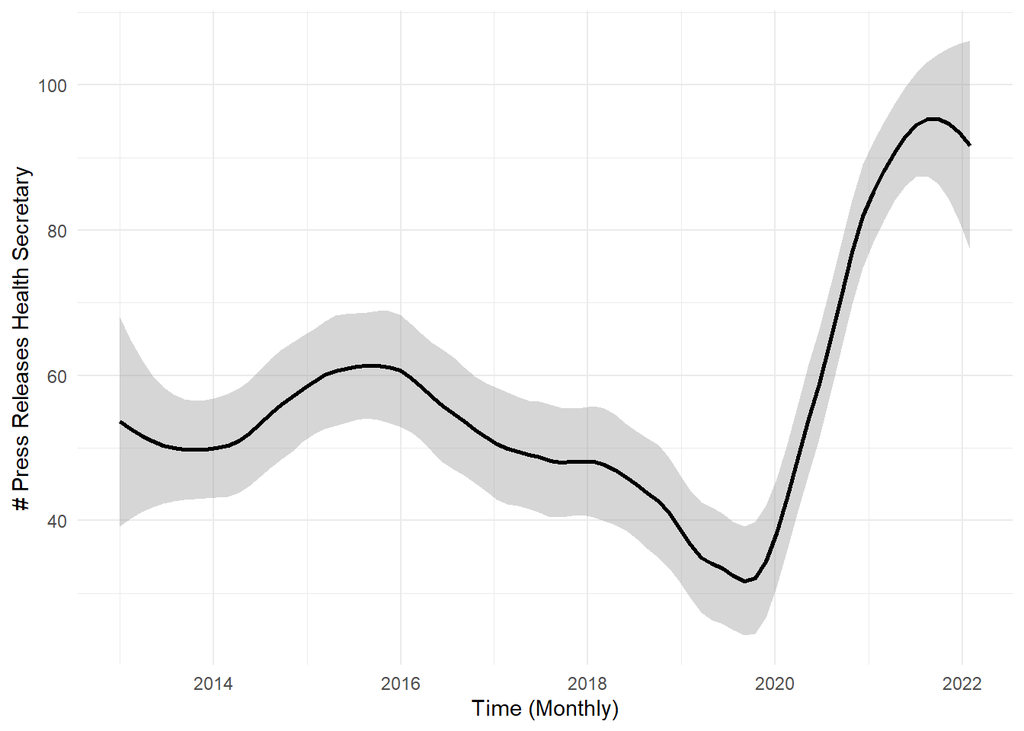

```r
load("data/data_comunicados_salud_21022022.RData")

data_comunicados <- data_comunicados %>% filter(date>="2013-01-01")
data_comunicados <- data_comunicados %>%
  mutate(date_month = as.Date(paste0(gsub("\\d{2}$","",date),"01")))
data_comunicados <- data_comunicados %>% mutate(text_full = paste0(titulo," ",entrada," ", texto_cuerpo))

daily_texts <- data_comunicados %>%
  group_by(date) %>% summarise(text = paste0(text_full, collapse = " "))

time_aggr <- data_comunicados %>%
  group_by(date_month) %>%
  tally()

ggplot(time_aggr, aes(date_month, n)) + geom_smooth(span = 0.4, colour = "black") + ylab("# Press Releases Health Secretary") +
  xlab("Time (Monthly)") + theme_minimal()
```

```r
ggsave(filename="results/press_releases_number.png",
      plot=last_plot(), device="png", units="cm", width=20, height=8, dpi=300)
```

## Uploading dictionary

```r
dictionary.reputation <- openxlsx::read.xlsx("data/ReputationDimensions_Dictionary_v1.xlsx") %>%
  filter(!is.na(palabra))

dictionary.reputation <- quanteda::dictionary(list(
  funcional = dictionary.reputation %>%#
    filter(dictionary=="funcional") %>% dplyr::select(palabra) %>% unlist() %>%  c(),
  legal = dictionary.reputation %>%
    filter(dictionary=="legal") %>% dplyr::select(palabra) %>%  unlist() %>%  c(),
  moral = dictionary.reputation %>%
    filter(dictionary=="moral") %>% dplyr::select(palabra) %>% unlist() %>%  c(),
  tecnico = dictionary.reputation %>%
    filter(dictionary=="tecnico") %>% dplyr::select(palabra) %>% unlist() %>%  c()
))
```

## Analysis press releases

Defining corpus and extracting reputation strategic dimension frequencies

```r
press_corpus  <- quanteda::corpus(daily_texts, text_field= "text")

press_tokens <- quanteda::tokens(press_corpus,
                                 remove_punct = FALSE,
                                 remove_symbols=FALSE,
                                 remove_separators=FALSE,
                                 split_hyphens = TRUE,
                                 remove_numbers = FALSE,
                                 remove_url=FALSE) %>% quanteda::tokens_tolower()

press_dfm <- quanteda::dfm(press_tokens,
                           dictionary = c(dictionary.reputation))

daily_texts <- daily_texts %>% bind_cols(press_dfm %>% as.data.frame())

rm(press_corpus, press_tokens, press_dfm)
```

## Merge Twitter and Covid-19 death toll data

```r
daily_texts <- daily_texts %>% left_join(tw.daily_sentiment.legit)

daily_texts <- daily_texts %>% mutate(words = ntoken(text))

daily_texts <- daily_texts %>% left_join(covid.deaths)

daily_texts <- daily_texts %>%
  mutate(across(c(funcional:tecnico), ~ ./words*100, .names = "{.col}_share")) %>%
  mutate(across(c(funcional_share:tecnico_share), ~ .-mean(.), .names = "{.col}.cent"))
```

## New indicadores data for press releases

```r
data_indicadores <- daily_texts %>%
  dplyr::select(date, deaths, deaths_week.ma, sentiment, sentiment_week.ma,
                funcional_share.cent:tecnico_share.cent) %>%
  pivot_longer(!date, names_to = "dimension", values_to = "value")

data_indicadores <- data_indicadores %>% group_by(dimension) %>%
  mutate(mean_dimension = mean(value, na.rm = TRUE)) %>%
  ungroup() %>%
  mutate(indicador = value-mean_dimension+0)
```

## Visualize new data

This code generates Figure 1 of the paper: “Reputational Dimensions in Press Releases by the Health Secretariat, 2013-2022”.

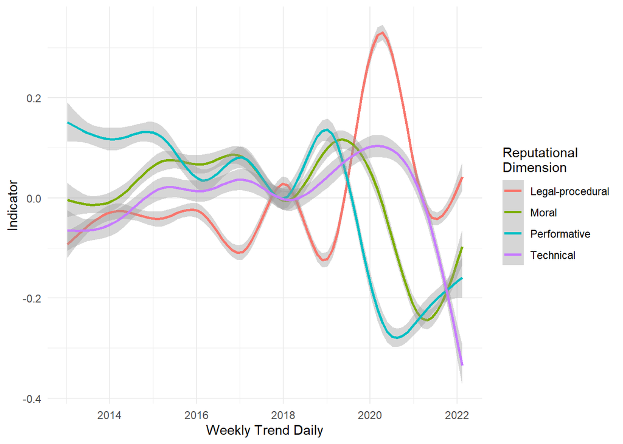

```r
data_indicadores <- data_indicadores %>% ungroup() %>% arrange(dimension,date) %>% group_by(dimension) %>%
  mutate(indicador_week.ma = zoo::rollapply(indicador,7, mean, align='right', fill=NA)) %>% ungroup() %>%
  mutate(`Reputational dimension` = case_when(dimension == "funcional_share.cent" ~ "Performative",
                                              dimension == "legal_share.cent" ~ "Legal-procedural",
                                              dimension == "tecnico_share.cent" ~ "Technical",
                                              dimension == "moral_share.cent" ~ "Moral"))

reputation_gr <- ggplot(data_indicadores %>% dplyr::rename(`Reputational\nDimension` = `Reputational dimension`) %>%
                          filter(!grepl("Flesch|senti[.]ton|senti|actor", `Reputational\nDimension`)) %>%
                          filter(!is.na(`Reputational\nDimension`)),
                        aes(x = date, y = indicador_week.ma,  colour = `Reputational\nDimension`)) +
  geom_smooth(span = 0.5) + theme_minimal() + xlab("Weekly Trend Daily") + ylab("Indicator")

deaths_gr <- ggplot(data_indicadores %>% filter(dimension=="deaths"))+ ylab("Daily Deaths") + xlab("Date") +
  geom_area(aes(x = date, y = value), fill="grey", colour="black", size = 1) + theme_minimal()

# reputation_gr/deaths_gr

reputation_gr
```

## Last press release transformation before analysis

```r
data_meta <- daily_texts %>% dplyr::select(date, deaths, deaths_week.ma, sentiment, sentiment_week.ma) %>%
  filter(!duplicated(.))

data_indicadores <- data_indicadores %>% left_join(data_meta)

data_indicadores <- data_indicadores %>% arrange(dimension, date) %>%
  group_by(dimension) %>%
  mutate(lead.indicador = dplyr::lead(indicador, n = 1, default = NA),
         lead.deaths = dplyr::lead(deaths, n = 1, default = NA),
         lead.value = dplyr::lead(value, n = 1, default = NA),
         lead.sentiment = dplyr::lead(sentiment , n = 1, default = NA),
         id = row_number()) %>% ungroup() %>%
  mutate(indicador_change = lead.indicador-indicador,
         deaths_change = lead.deaths-deaths)
```

## VAR models - press releases, Table 7 in SM 5

```r
stargazer::stargazer(`Performative--DimensionByDeaths`,
                     `Performative--DimensionByAll`,
                     `Technical--DimensionByDeaths`,
                     `Technical--DimensionByAll`,
                     `Legal-procedural--DimensionByDeaths`,
                     `Legal-procedural--DimensionByAll`,
                     `Moral--DimensionByDeaths`,
                     `Moral--DimensionByAll`,
                     type = "html", style = "apsr", report = "vc*sp",
                     column.labels = c(rep("Performative",2), rep("Technical",2), rep("Legal",2), rep("Moral",2)),
                     covariate.labels = c("Reputation dimension, t-1", "Covid-19 deaths t-1 - t-7, average",
                                          "Public Sentiment -> Organization t-1 - t-7, average"))
```

|  | issue_ts |  |  |  |  |  |  |  |
| --- | --- | --- | --- | --- | --- | --- | --- | --- |
|  | Performative | Performative | Technical | Technical | Legal | Legal | Moral | Moral |
|  | (1) | (2) | (3) | (4) | (5) | (6) | (7) | (8) |
| Reputation dimension, t-1 | 0.275*** | 0.273*** | 0.428*** | 0.406*** | 0.536*** | 0.522*** | 0.035 | 0.034 |
|  | (0.046) | (0.046) | (0.043) | (0.044) | (0.040) | (0.041) | (0.048) | (0.048) |
|  | p = 0.000 | p = 0.000 | p = 0.000 | p = 0.000 | p = 0.000 | p = 0.000 | p = 0.469 | p = 0.483 |
| Covid-19 deaths t-1 - t-7, average | 0.0001 | 0.0001 | 0.0002*** | 0.0001*** | -0.0001 | -0.0001 | -0.00001 | -0.00001 |
|  | (0.00005) | (0.00005) | (0.00005) | (0.00005) | (0.00005) | (0.00005) | (0.00004) | (0.00004) |
|  | p = 0.133 | p = 0.116 | p = 0.001 | p = 0.003 | p = 0.187 | p = 0.103 | p = 0.858 | p = 0.782 |
| Public Sentiment -> Organization t-1 - t-7, average |  | 0.116 |  | -0.537*** |  | -0.373** |  | -0.110 |
|  |  | (0.191) |  | (0.192) |  | (0.189) |  | (0.157) |
|  |  | p = 0.545 |  | p = 0.006 |  | p = 0.049 |  | p = 0.485 |
| Constant | -0.247*** | -0.165 | -0.045 | -0.427*** | 0.115*** | -0.147 | -0.183*** | -0.262** |
|  | (0.033) | (0.138) | (0.029) | (0.140) | (0.030) | (0.135) | (0.025) | (0.115) |
|  | p = 0.000 | p = 0.234 | p = 0.119 | p = 0.003 | p = 0.0002 | p = 0.279 | p = 0.000 | p = 0.023 |
| N | 437 | 437 | 437 | 437 | 437 | 437 | 437 | 437 |
| R<sup>2</sup> | 0.084 | 0.085 | 0.237 | 0.251 | 0.300 | 0.306 | 0.001 | 0.002 |
| Adjusted R<sup>2</sup> | 0.080 | 0.079 | 0.234 | 0.246 | 0.297 | 0.301 | -0.003 | -0.004 |
| Residual Std. Error | 0.298 (df = 434) | 0.298 (df = 433) | 0.298 (df = 434) | 0.295 (df = 433) | 0.291 (df = 434) | 0.290 (df = 433) | 0.245 (df = 434) | 0.245 (df = 433) |
| F Statistic | 19.973*** (df = 2; 434) | 13.419*** (df = 3; 433) | 67.479*** (df = 2; 434) | 48.290*** (df = 3; 433) | 92.973*** (df = 2; 434) | 63.706*** (df = 3; 433) | 0.280 (df = 2; 434) | 0.350 (df = 3; 433) |
| p < .1; p < .05; p < .01 |  |  |  |  |  |  |  |  |

# Comparing indicators

Comparing reputational strategic dimension indicators from press releases and press conferences by the Health Secretariat during the Covid-19 public health crisis

This code generate Table 4 in Suppplementary Material 2: “Table 4. Reputational Dimension Correlations between Press Conferences and Press Releases, Mexican Health Secretariat 2020-2021 (day level)”.

```r
indicadores_conferencia <- data_indicadores.conferences %>%
  dplyr::select(date, dimension, indicador) %>%
  filter(grepl("cent", dimension))

indicadores_press.releases <- data_indicadores %>% dplyr::select(date, dimension, indicador) %>%
  ungroup() %>%
  filter(grepl("cent", dimension)) %>% dplyr::rename(indicador_press.releases = indicador)

indicadores <- left_join(indicadores_conferencia, indicadores_press.releases)
rm(indicadores_conferencia, indicadores_press.releases)
```

Functional-performative dimension correlation

```r
cor.test(indicadores$indicador[indicadores$dimension=="funcional_share.cent"],
         indicadores$indicador_press.releases[indicadores$dimension=="funcional_share.cent"])
```

```
##
##  Pearson's product-moment correlation
##
## data:  indicadores$indicador[indicadores$dimension == "funcional_share.cent"] and indicadores$indicador_press.releases[indicadores$dimension == "funcional_share.cent"]
## t = 10.047, df = 426, p-value < 0.00000000000000022
## alternative hypothesis: true correlation is not equal to 0
## 95 percent confidence interval:
##  0.3577260 0.5112497
## sample estimates:
##       cor
## 0.4376724
```

Legal dimension correlation

```r
cor.test(indicadores$indicador[indicadores$dimension=="legal_share.cent"],
         indicadores$indicador_press.releases[indicadores$dimension=="legal_share.cent"])
```

```
##
##  Pearson's product-moment correlation
##
## data:  indicadores$indicador[indicadores$dimension == "legal_share.cent"] and indicadores$indicador_press.releases[indicadores$dimension == "legal_share.cent"]
## t = 4.1859, df = 426, p-value = 0.00003453
## alternative hypothesis: true correlation is not equal to 0
## 95 percent confidence interval:
##  0.1059691 0.2881182
## sample estimates:
##       cor
## 0.1987594
```

Technical dimension correlation

```r
cor.test(indicadores$indicador[indicadores$dimension=="tecnico_share.cent"],
         indicadores$indicador_press.releases[indicadores$dimension=="tecnico_share.cent"])
```

```
##
##  Pearson's product-moment correlation
##
## data:  indicadores$indicador[indicadores$dimension == "tecnico_share.cent"] and indicadores$indicador_press.releases[indicadores$dimension == "tecnico_share.cent"]
## t = 7.4247, df = 426, p-value = 0.0000000000006209
## alternative hypothesis: true correlation is not equal to 0
## 95 percent confidence interval:
##  0.2517838 0.4198096
## sample estimates:
##       cor
## 0.3384922
```

Moral dimension correlation

```r
cor.test(indicadores$indicador[indicadores$dimension=="moral_share.cent"],
         indicadores$indicador_press.releases[indicadores$dimension=="moral_share.cent"])
```

```
##
##  Pearson's product-moment correlation
##
## data:  indicadores$indicador[indicadores$dimension == "moral_share.cent"] and indicadores$indicador_press.releases[indicadores$dimension == "moral_share.cent"]
## t = 3.9359, df = 426, p-value = 0.0000968
## alternative hypothesis: true correlation is not equal to 0
## 95 percent confidence interval:
##  0.09420333 0.27718290
## sample estimates:
##       cor
## 0.1873175
```

# Dicitionary, adapted in Spanish

Primary source: Busuioc, Madalina, and Dovilė Rimkutė. 2020. Meeting expectations in the EU regulatory state? Regulatory communications amid conflicting institutional demands. Journal of European Public Policy 27(4): 547–568.

```r
dictionary.reputation <- openxlsx::read.xlsx("data/reputationDimensions_Dictionary_v1.xlsx") %>%
  filter(!is.na(palabra))
```

Functional-performative dimension wording

```r
as.character(dictionary.reputation %>% filter(dictionary=="funcional") %>% dplyr::select(palabra) %>%
  summarise(paste0(., collapse = ", "))) %>% gsub('["]',"",.)
```

```
## [1] "c(aplica*, apliqu*, impon*, ejecut*, pong* en vigor, pone* en vigor, resultad*, éxito*, cumplid*, logro*, hazaña*, ejecuci*, acció*, accio*, adopt* la* decisi*, adopt* un* decisi*, aplicaci*, implementac*, afirmativ*, asertiv*, conformida*, conform*, efectiv*, eficien*, eficaz*, compete*, me…
```

Legal dimension wording

```r
as.character(dictionary.reputation %>% filter(dictionary=="legal") %>% dplyr::select(palabra) %>%
  summarise(paste0(., collapse = ", "))) %>% gsub('["]',"",.)
```

```
## [1] "c(consult*, formal*, independient*, protocol*, proceso*, procedimient*, autoridad*, norma, normas, normativa*, mando, pauta, regla*, el principio, los principios, acce* a docum*, acce* a lo* docum*, acce* a informaci*, acce* a la* informaci*, apele*, apela*, recurrir, conflicto* de inter*, s…
```

Moral dimension wording

```r
as.character(dictionary.reputation %>% filter(dictionary=="moral") %>% dplyr::select(palabra) %>%
  summarise(paste0(., collapse = ", "))) %>% gsub('["]',"",.)
```

```
## [1] "c(proteg*, protecci`*, valores, comprometid* con, interes común, intereses comunes, consumid*, credibilidad*, dialog*, compromis*, étic*, flexib*, buena gestión, buna gobernanza, buen gobierno, gestión positiva, buena administración, honest*, sincer*, franco, franca, íntegr*, inclusiv*, inte…
```

Technical dimension wording

```r
as.character(dictionary.reputation %>% filter(dictionary=="tecnico") %>% dplyr::select(palabra) %>%
  summarise(paste0(., collapse = ", "))) %>% gsub('["]',"",.)
```

```
## [1] "c(segur*, confiab*, riguros*, test*, prueba*, proba*, probe*, evalua*, calcul*, análisis, analiz*, dato*, data, evidenci*, examin*, expert*, investig*, conocimient*, probabilid*, metodolog*, metódic*, model*, profesional*, cualitativ*, cuantifiq*, cuantific*, cuantitativ*, investig*, estudi*…
```